# ビッグデータ統計解析入門（Chapter 7）

五十嵐未来

2019年4月17日

## Chapter 7『テキスト解析と自然言語処理』

### データセット

使用するデータはRの`lda`パッケージに含まれている20 newsgroupデータセットであり、以下のようにしてR上にインポートできます。

```r
library(lda)
data(newsgroup.train.documents)
data(newsgroup.vocab)
data(newsgroup.train.labels)
data(newsgroup.label.map)
```

それぞれのデータの詳細は以下の通りです。

- `.documents`は、各文書に・どのような単語が・どのくらいの頻度で含まれているかを表すメインのデータであり、次のように、そのまま`lda.collapsed.gibbs.sampler`に渡せる形となっています。

```r
newsgroup.train.documents[[1]][,1:20] # word indicators (1st row) and frequencies (2nd row) of 1-20th words in 1st document
```

```
##      [,1] [,2] [,3] [,4] [,5] [,6] [,7] [,8] [,9] [,10] [,11] [,12] [,13]
## [1,]    0    1    2    3    4    5    6    7    8     9    10    11    12
## [2,]    4    2   10    4    2    1    1    1    3     9     2    58     1
##      [,14] [,15] [,16] [,17] [,18] [,19] [,20]
## [1,]    13    14    15    16    17    18    19
## [2,]     4     2    13     6     2     4     6
```

- `.vocab`は、単語を示す数字と実際の単語とを対応づける辞書です。ただし、`.documents`の数字が0始まりであることに注意が必要です（`.documents`内の0番目の単語と`.vocab[1]`の単語が対応するので、1番目の文書では“archive”という単語が4回、“name”という単語が2回出現しています）。

```r
newsgroup.vocab[1:20]
```

```
##  [1] "archive"       "name"          "atheism"       "resources"
##  [5] "alt"           "last"          "modified"      "december"
##  [9] "version"       "atheist"       "addresses"     "of"
## [13] "organizations" "usa"           "freedom"       "from"
## [17] "religion"      "foundation"    "darwin"        "fish"
```

- `.labels`は、各文書の正解ラベルであり、`.label.map`と組み合わせることで記事の正解トピックが分かります。小分類は以下のように20種類ですが、[データの配布元](http://qwone.com/~jason/20Newsgroups/)を参照すると表のように6種類の大分類に分けることが出来ます。

```r
str(newsgroup.train.labels)
```

```
##  int [1:11269] 1 1 1 1 1 1 1 1 1 1 ...
```

[output not shown]

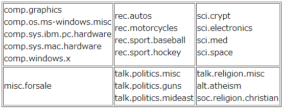

```r
newsgroup.label.map
```

### 課題

このデータセットを使って以下のタスクを実行してください。

- 記事を大分類で分け、それぞれについてワードクラウドを作成することで、データの全体的な傾向を説明せよ。
- LDAモデルを（collapsed Gibbs samplerを用いて）推定せよ。ただし、ハイパーパラメータのαやβ、及びトピック数は各自で様々な値を調整すること。また、データ数が多く、推定に時間がかかるため、`lda.collapsed.gibbs.sampler`関数を実行する際に`trace=1L`を指定し、進捗を表示するとよい。
- 推定結果について議論せよ。例えば、各トピックの所属確率上位の単語を見ることでトピックの解釈を行ったり、文書ごとに推定されるトピック分布を正解ラベル（あるいは大分類）に従って集計することでクラスターの特徴を議論したりなどが考えられる。

### 発展

ldaパッケージからインポートできるデータは既に前処理や整形が済んだデータです。しかし、現実のテキスト解析では、収集した生のテキストデータを分析できる形に処理する工程が必要不可欠です。[データの配布元](http://qwone.com/~jason/20Newsgroups/)の20news-bydate.tar.gzをダウンロードすると、前処理などが行われていない生のテキストデータを取得することが出来ます。このデータを処理・整形し、上の課題を行うことはより実践的であり、力がつくはずですので、余力のある人はぜひ取り組んでみてください。

テキストデータの前処理とは、今回のデータで言えば、以下のような処理をすることで分析可能な形に整形することができます。それぞれの詳細については説明しませんので、テキストマイニングの本などを参照してください。

- テキストのメタデータを削除する  
  （生データには記事の作成者やキーワードといったメタ情報がヘッダとして本文の前に付随している）
- ストップワードを削除する  
  （a, I, do, ofなど意味の薄い英単語や、<…@…>などの形のメールアドレス、暦を表す単語、記号や数字列といったようにテキストの特徴に応じて様々なストップワードが考えられる）
- 表記の揺れを統一する  
  （COME, Come, came, comingなどを全てcomeに統一するなど）
- 単語に区切る  
  （教科書の例は日本語であるためMeCabを使ったが、今回は英語のため空白で分ければよい）
- 品詞を絞る  
  （ニュース記事であるため名詞のみで十分特徴を捉えることが出来るが、例えばキャッチコピーなどは文章のニュアンスが重要であり、動詞や形容詞なども含めて分析した方が良い場合もある）
- 頻度情報から分析に用いる単語を絞る  
  （全体を通してあまり出てこない単語や、逆に多くの文書で出てくる単語は、テキストの要約には重要でないだけでなく、外れ値としてモデルの推定に悪影響を与えることがある）